# R Notebook: IMDB (predict gender from biography)

```r
library(devtools);
library(humanVerseWSU);

path.github = "https://raw.githubusercontent.com/MonteShaffer/humanVerseWSU/master/";

include.me = paste0(path.github, "misc/functions-nlp.R");
source_url( include.me );
```

```
## SHA-1 hash of file is d411302cf0069ed51cc5dfb8c1163a7869329eed
```

```r
include.me = paste0(path.github, "misc/functions-nlp-str.R");
source_url( include.me );
```

```
## SHA-1 hash of file is 54604c6aba08045f7965d86773bf15d7288a67fe
```

```r
include.me = paste0(path.github, "misc/functions-nlp-stack.R");
source_url( include.me );
```

```
## SHA-1 hash of file is fb9b84a774f8d46c97db92eabfc7ae778b49cfeb
```

```r
include.me = paste0(path.github, "misc/functions-nlp-pos.R");
source_url( include.me );
```

```
## SHA-1 hash of file is c4185150c8c43a59e88093872bef9c0fb4bc1dc5
```

```r
include.me = paste0(path.github, "humanVerseWSU/R/functions-encryption.R");
source_url( include.me );
```

```
## SHA-1 hash of file is da71dde620bed33db055778b752eefb476f7bf6b
```

```r
path.to.nascent = "C:/Users/Alexander Nevsky/Dropbox/WSU-419/Fall 2020/__student_access__/unit_02_confirmatory_data_analysis/nascent/";

folder.nlp = "nlp/";
path.to.nlp = paste0(path.to.nascent, folder.nlp);


###### UPDATES TO dataframe subset function ######
# inflation adjustments for NA ... and improvements on subsetting
include.me = paste0(path.github, "humanVerseWSU/R/functions-dataframe.R");
source_url( include.me );
```

```
## SHA-1 hash of file is 1149cbf3e865f692b50d4d1983e6364dc56ce62d
```

```r
include.me = paste0(path.github, "humanVerseWSU/R/functions-inflation.R");
source_url( include.me );
```

```
## SHA-1 hash of file is b6d29327e3fe030ca132b135f4a89b6fc6a61a66
```

# 1 (IMDB) Custom library

This is a large dataset I harvested in September. It will allow us to explore more comprehensively the relationships of various features of the movie database. It is large (about 50MB), so installing may take some time if you are on a slow internet connection.

This dataset will be the source you will use on your final exam to answer the question posed earlier in the semester about Will Smith and Denzel Washington. You now have more analytics skills and with the new dataset there are more features you can extract.

```r
# library(devtools);
# install_github("MonteShaffer/imdb/imdb"); # choose #3 to humanVerseWSU
# detach(package:imdb);
library(imdb);
packageVersion("imdb");  # ‘0.1.1’
```

```
## [1] '0.1.1'
```

```r
# ?loadDataIMDB
```

## 1.1 Load data

Once this is run, a lot of memory will be required to read in the 23 compressed files.

```r
imdb::loadDataIMDB();
names(imdb.data);
```

```
##  [1] "all.movies.creatives"         "all.movies.companies"
##  [3] "all.movies.actors.characters" "all.actors.rank"
##  [5] "all.actors.movies"            "all.actors.info"
##  [7] "moviecount.byyear"            "actors"
##  [9] "glue"                         "headliners"
## [11] "movies"                       "movies.df"
```

```r
humanVerseWSU::loadInflationData();
```

A global variable is automatically created with several dataframes.

### 1.1.1 Data Dictionary

#### 1.1.1.1 Movie Count by Year

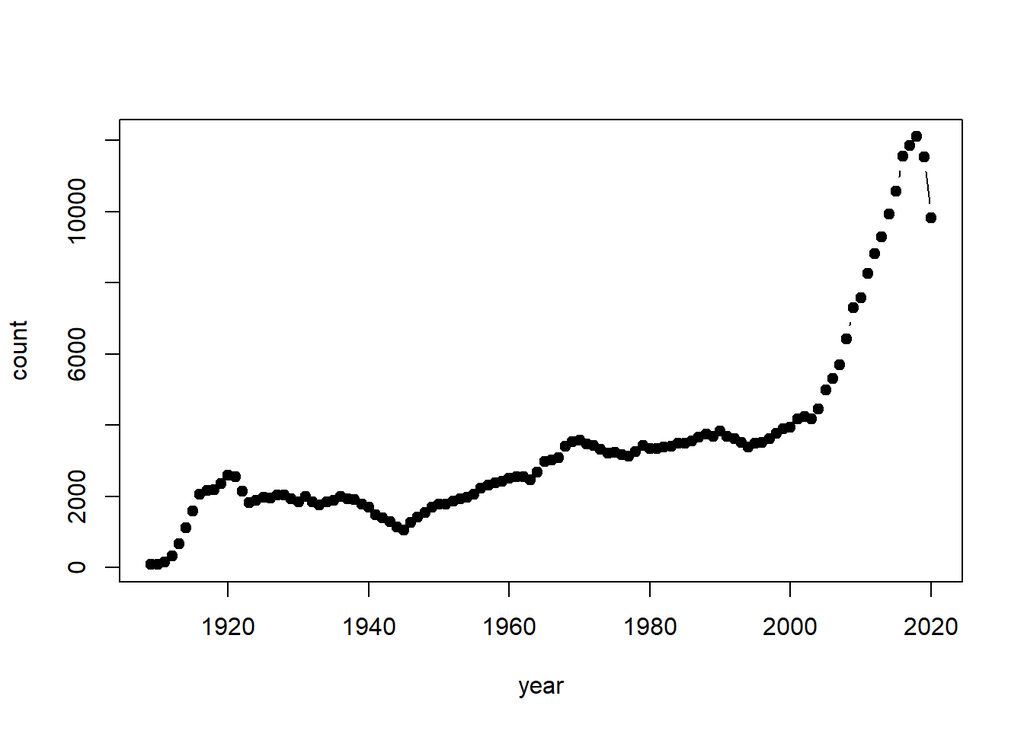

```r
plot(imdb.data$moviecount.byyear, type="b", pch=19);
```

Even though I harvested this data in September 2020, it seems there was a movie fall-off in 2019, before COVID. Often this can be understood using change-point analyses. Maybe it is linked to a “Trump-factor”; the media suggests that money is moved from block-buster movies into streaming options (Netflix, and so on). It is an interesting question.

#### 1.1.1.2 Lists: movies

- all :: defined as the unique “ttid”s of all other lists

```r
length(imdb.data$movies$all);
```

```
## [1] 74520
```

```r
head(imdb.data$movies$all, 20);
```

```
##  [1] "tt0000001" "tt0000002" "tt0000003" "tt0000004" "tt0000005" "tt0000006"
##  [7] "tt0000007" "tt0000008" "tt0000009" "tt0000010" "tt0000011" "tt0000012"
## [13] "tt0000013" "tt0000014" "tt0000015" "tt0000016" "tt0000017" "tt0000018"
## [19] "tt0000019" "tt0000020"
```

- top250 :: < https://www.imdb.com/chart/top> Accessed September 2020.

```r
length(imdb.data$movies$top250);
```

```
## [1] 250
```

```r
head(imdb.data$movies$top250, 20);
```

```
##  [1] "tt0012349" "tt0015324" "tt0015864" "tt0017136" "tt0017925" "tt0018773"
##  [7] "tt0019254" "tt0021749" "tt0022100" "tt0025316" "tt0027977" "tt0031381"
## [13] "tt0031679" "tt0032553" "tt0032976" "tt0033467" "tt0034583" "tt0035446"
## [19] "tt0036775" "tt0038650"
```

- popular50 (dataframe) :: top-50 most popular for each year (by votes)

```r
dim(imdb.data$movies$popular50);
```

```
## [1] 5704    3
```

```r
names(imdb.data$movies$popular50);
```

```
## [1] "ttid"         "year"         "rank.popular"
```

```r
head(imdb.data$movies$popular50, 20);
```

|  | ttid | year | rank.popular |
| --- | --- | --- | --- |
| 1 | tt0219574 | 1898 | 1 |
| 2 | tt0229287 | 1898 | 2 |
| 3 | tt0221384 | 1898 | 3 |
| 4 | tt0229399 | 1898 | 4 |
| 5 | tt0237889 | 1898 | 5 |
| 6 | tt0229764 | 1898 | 6 |
| 7 | tt0229389 | 1898 | 7 |
| 8 | tt0221654 | 1898 | 8 |
| 9 | tt0317653 | 1898 | 9 |
| 10 | tt0237861 | 1898 | 10 |

[output cut: 10 more lines]

- gem50 (dataframe) :: top-50 highest rated for each year (by ratings)

```r
dim(imdb.data$movies$gem50);
```

```
## [1] 5704    3
```

```r
names(imdb.data$movies$gem50);
```

```
## [1] "ttid"     "year"     "rank.gem"
```

```r
head(imdb.data$movies$gem50, 20);
```

|  | ttid | year | rank.gem |
| --- | --- | --- | --- |
| 1 | tt0219574 | 1898 | 1 |
| 10 | tt0237861 | 1898 | 2 |
| 2 | tt0229287 | 1898 | 3 |
| 12 | tt0138538 | 1898 | 4 |
| 14 | tt0317654 | 1898 | 5 |
| 5 | tt0237889 | 1898 | 6 |
| 11 | tt0237775 | 1898 | 7 |
| 15 | tt0229690 | 1898 | 8 |
| 8 | tt0221654 | 1898 | 9 |
| 3 | tt0221384 | 1898 | 10 |

[output cut: 10 more lines]

- tt5000 :: numeric movie ids from 1:5000 several bad ones … length is less than that.

```r
length(imdb.data$movies$tt5000);
```

```
## [1] 4942
```

```r
head(imdb.data$movies$tt5000, 20);
```

```
##  [1] "tt0000001" "tt0000002" "tt0000003" "tt0000004" "tt0000005" "tt0000006"
##  [7] "tt0000007" "tt0000008" "tt0000009" "tt0000010" "tt0000011" "tt0000012"
## [13] "tt0000013" "tt0000014" "tt0000015" "tt0000016" "tt0000017" "tt0000018"
## [19] "tt0000019" "tt0000020"
```

#### 1.1.1.3 Lists: actors

- all :: defined as the unique “nmid”s of all other lists

```r
length(imdb.data$actors$all);
```

```
## [1] 71341
```

```r
head(imdb.data$actors$all, 20);
```

```
##  [1] "nm0000001" "nm0000002" "nm0000003" "nm0000004" "nm0000005" "nm0000006"
##  [7] "nm0000007" "nm0000008" "nm0000009" "nm0000010" "nm0000011" "nm0000012"
## [13] "nm0000013" "nm0000014" "nm0000015" "nm0000016" "nm0000017" "nm0000018"
## [19] "nm0000019" "nm0000020"
```

- top250 :: < https://www.imdb.com/chart/top> Accessed September 2020. These are the actors on those movies

```r
length(imdb.data$actors$top250);
```

```
## [1] 3092
```

```r
head(imdb.data$actors$top250, 20);
```

```
##  [1] "nm0000002" "nm0000006" "nm0000007" "nm0000008" "nm0000012" "nm0000017"
##  [7] "nm0000018" "nm0000020" "nm0000021" "nm0000022" "nm0000023" "nm0000024"
## [13] "nm0000026" "nm0000027" "nm0000032" "nm0000034" "nm0000036" "nm0000037"
## [19] "nm0000038" "nm0000044"
```

- popular50 :: top-50 most popular for each year (by votes)

```r
length(imdb.data$actors$popular50);
```

```
## [1] 35245
```

```r
head(imdb.data$actors$popular50, 20);
```

```
##  [1] "nm0000001" "nm0000002" "nm0000003" "nm0000004" "nm0000006" "nm0000007"
##  [7] "nm0000008" "nm0000009" "nm0000010" "nm0000011" "nm0000012" "nm0000013"
## [13] "nm0000014" "nm0000015" "nm0000017" "nm0000018" "nm0000020" "nm0000021"
## [19] "nm0000022" "nm0000023"
```

- gem50 :: top-50 highest rated for each year (by ratings)

```r
length(imdb.data$actors$gem50);
```

```
## [1] 37997
```

```r
head(imdb.data$actors$gem50, 20);
```

```
##  [1] "nm0000001" "nm0000002" "nm0000006" "nm0000007" "nm0000008" "nm0000010"
##  [7] "nm0000011" "nm0000012" "nm0000014" "nm0000017" "nm0000018" "nm0000019"
## [13] "nm0000020" "nm0000021" "nm0000022" "nm0000023" "nm0000024" "nm0000026"
## [19] "nm0000027" "nm0000028"
```

```r
length(imdb.data$actors$tt5000);
```

```
## [1] 5452
```

```r
head(imdb.data$actors$tt5000, 20);
```

```
##  [1] "nm0000122" "nm0000252" "nm0000406" "nm0000428" "nm0000779" "nm0000856"
##  [7] "nm0000858" "nm0000859" "nm0000875" "nm0000891" "nm0001273" "nm0001316"
## [13] "nm0001366" "nm0001908" "nm0002001" "nm0002031" "nm0002034" "nm0002061"
## [19] "nm0002118" "nm0002154"
```

- nm5000 :: numeric actor ids from 1:5000 several bad ones … length is less than that.

```r
length(imdb.data$actors$nm5000);
```

```
## [1] 4968
```

```r
head(imdb.data$actors$nm5000, 20);
```

```
##  [1] "nm0000001" "nm0000002" "nm0000003" "nm0000004" "nm0000005" "nm0000006"
##  [7] "nm0000007" "nm0000008" "nm0000009" "nm0000010" "nm0000011" "nm0000012"
## [13] "nm0000013" "nm0000014" "nm0000015" "nm0000016" "nm0000017" "nm0000018"
## [19] "nm0000019" "nm0000020"
```

- headliners :: actors that were the “headliners” in 15 or more movies (from `imdb.data$glue$movies.creatives`). This is equivalent to `imdb.data$headliners$actors`.

```r
length(imdb.data$actors$headliners);
```

```
## [1] 2407
```

```r
head(imdb.data$actors$headliners, 20);
```

```
##  [1] "nm0000001" "nm0000002" "nm0000003" "nm0000006" "nm0000007" "nm0000008"
##  [7] "nm0000009" "nm0000010" "nm0000011" "nm0000012" "nm0000013" "nm0000014"
## [13] "nm0000017" "nm0000018" "nm0000020" "nm0000021" "nm0000022" "nm0000023"
## [19] "nm0000024" "nm0000026"
```

#### 1.1.1.4 Lists: headliners

A headliner has a lot of experience as a top-3 (either writer, director, actor, or company);

- actors :: actors that were the “headliners” in 15 or more movies

```r
length(imdb.data$headliners$actors);
```

```
## [1] 2407
```

```r
head(imdb.data$headliners$actors, 20);
```

```
##  [1] "nm0000001" "nm0000002" "nm0000003" "nm0000006" "nm0000007" "nm0000008"
##  [7] "nm0000009" "nm0000010" "nm0000011" "nm0000012" "nm0000013" "nm0000014"
## [13] "nm0000017" "nm0000018" "nm0000020" "nm0000021" "nm0000022" "nm0000023"
## [19] "nm0000024" "nm0000026"
```

- directors :: directors that were the “headliners” in 15 or more movies

```r
length(imdb.data$headliners$directors);
```

```
## [1] 606
```

```r
head(imdb.data$headliners$directors, 20);
```

```
##  [1] "nm0000005" "nm0000033" "nm0000036" "nm0000041" "nm0000080" "nm0000095"
##  [7] "nm0000108" "nm0000110" "nm0000118" "nm0000122" "nm0000127" "nm0000142"
## [13] "nm0000165" "nm0000180" "nm0000217" "nm0000229" "nm0000231" "nm0000265"
## [19] "nm0000318" "nm0000338"
```

- writers :: writers that were the “headliners” in 15 or more movies

```r
length(imdb.data$headliners$writers);
```

```
## [1] 670
```

```r
head(imdb.data$headliners$writers, 20);
```

```
##  [1] "nm0000005" "nm0000019" "nm0000041" "nm0000076" "nm0000080" "nm0000095"
##  [7] "nm0000108" "nm0000116" "nm0000118" "nm0000122" "nm0000175" "nm0000184"
## [13] "nm0000230" "nm0000231" "nm0000233" "nm0000252" "nm0000338" "nm0000341"
## [19] "nm0000361" "nm0000390"
```

- companies :: companies that were the “headliners” in 15 or more movies

```r
length(imdb.data$headliners$companies);
```

```
## [1] 770
```

```r
head(imdb.data$headliners$companies, 20);
```

```
##  [1] "co0002663" "co0007143" "co0023400" "co0050868" "co0005073" "co0000756"
##  [7] "co0002219" "co0053157" "co0007001" "co0041421" "co0022792" "co0028557"
## [13] "co0020540" "co0028775" "co0021358" "co0024010" "co0067278" "co0046718"
## [19] "co0021661" "co0008970"
```

#### 1.1.1.5 Companies

These are the (at most) top-3 company credits plus the (at most) top-3 actors found in the “Details” section of a movie page.

```r
dim(imdb.data$all.movies.companies);
```

```
## [1] 120376      4
```

```r
names(imdb.data$all.movies.companies);
```

```
## [1] "ttid"    "co.rank" "coid"    "name"
```

```r
head(imdb.data$all.movies.companies, 20);
```

|  | ttid | co.rank | coid | name |
| --- | --- | --- | --- | --- |
| 121552 | tt0000001 | 1 | co0037035 | Edison Manufacturing Company |
| 121553 | tt0000002 | NA | NO-INFO |  |
| 121555 | tt0000003 | NA | NO-INFO |  |
| 121557 | tt0000004 | NA | NO-INFO |  |
| 121559 | tt0000005 | 1 | co0037035 | Edison Manufacturing Company |
| 121560 | tt0000006 | NA | NO-INFO |  |
| 121562 | tt0000007 | 1 | co0037035 | Edison Manufacturing Company |
| 121563 | tt0000008 | 1 | co0037035 | Edison Manufacturing Company |
| 121564 | tt0000009 | 1 | co0014292 | Alexander Black Photoplays |
| 121565 | tt0000010 | 1 | co0014436 | Lumière |

[output cut: 10 more lines]

#### 1.1.1.6 Creatives

These are the (at most) top-3 creatives plus the (at most) top-3 actors found at the top of a movie page.

```r
dim(imdb.data$all.movies.creatives);
```

```
## [1] 407481      4
```

```r
names(imdb.data$all.movies.creatives);
```

```
## [1] "ttid"          "creative.rank" "nmid"          "role"
```

```r
head(imdb.data$all.movies.creatives, 20);
```

|  | ttid | creative.rank | nmid | role |
| --- | --- | --- | --- | --- |
| 389665 | tt0000001 | 1 | nm0005690 | director |
| 389666 | tt0000001 | 2 | nm1588970 | star |
| 389667 | tt0000002 | 1 | nm0721526 | director |
| 389668 | tt0000003 | 1 | nm0721526 | director |
| 389669 | tt0000004 | 1 | nm0721526 | director |
| 389670 | tt0000005 | 1 | nm0005690 | director |
| 389671 | tt0000005 | 2 | nm0443482 | star |
| 389672 | tt0000005 | 3 | nm0653042 | star |
| 389673 | tt0000006 | 1 | nm0005690 | director |
| 389674 | tt0000007 | 1 | nm0005690 | director |

[output cut: 10 more lines]

#### 1.1.1.7 Actors: Info (e.g., Bio)

This is data from the top of an actor’s (any creative really) page: https://www.imdb.com/name/nm0000115/

```r
dim(imdb.data$all.actors.info);
```

```
## [1] 71332    10
```

```r
names(imdb.data$all.actors.info);
```

```
##  [1] "nmid"            "name"            "roles"           "born.when"
##  [5] "born.where"      "died.when"       "died.where"      "starmeter.rank"
##  [9] "starmeter.delta" "bio"
```

```r
head(imdb.data$all.actors.info, 20);
```

|  | nmid | name | roles | born.when | born.where | died.when | died.where | starmeter.rank | starmeter.delta | bio |
| --- | --- | --- | --- | --- | --- | --- | --- | --- | --- | --- |
| 1 | nm0000001 | Fred Astaire | Soundtrack,Actor,Miscellaneous Crew | 1899-5-10 | Omaha, Nebraska, USA | 1987-6-22 | Los Angeles, California, USA | NA | 990 | Fred Astaire was born in Omaha, Nebraska, to Johanna (Geilus) and Fritz Austerlitz, a brewer. Fred entered show business at age 5. He was successful both in vaudeville and on Broadway in partnership w… |
| 2 | nm0000002 | Lauren Bacall | Actress,Soundtrack | 1924-9-16 | The Bronx, New York City, New York, USA | 2014-8-12 | New York City, New York, USA | 5000 | -32 | Lauren Bacall was born Betty Joan Perske on September 16, 1924, in New York City. She was the daughter of Natalie Weinstein-Bacal, a Romanian Jewish immigrant, and William Perske, who was born in New … |
| 3 | nm0000003 | Brigitte Bardot | Actress,Soundtrack,Music Department | 1934-9-28 | Paris, France | NA | NA | 5000 | 201 | Brigitte Bardot was born on September 28, 1934 in Paris, France. Her father had an engineering degree and worked with his father in the family business. Brigitte's mother encouraged her daughter to ta… |
| 4 | nm0000004 | John Belushi | Actor,Writer,Soundtrack | 1949-1-24 | Chicago, Illinois, USA | 1982-3-5 | Hollywood, Los Angeles, California, USA | NA | 149 | John Belushi was born in Chicago, Illinois, USA, on January 24, 1949, to Agnes Demetri (Samaras) and Adam Anastos Belushi, a restaurant owner. His father was an Albanian immigrant, from Qytezë, and hi… |
| 5 | nm0000005 | Ingmar Bergman | Writer,Director,Actor | 1918-7-14 | Uppsala, Uppsala län, Sweden | 2007-7-30 | Fårö, Gotlands län, Sweden | 5000 | -64 | Ernst Ingmar Bergman was born July 14, 1918, the son of a priest. The film and T.V. series, The Best Intentions (1992) is biographical and shows the early marriage of his parents. The film 'Söndagsbar… |
| 6 | nm0000006 | Ingrid Bergman | Actress,Soundtrack,Producer | 1915-8-29 | Stockholm, Sweden | 1982-8-29 | Chelsea, London, England, UK | 5000 | 1065 | Ingrid Bergman was one of the greatest actresses from Hollywood's lamented Golden Era. Her natural and unpretentious beauty and her immense acting talent made her one of the most celebrated figures in… |
| 7 | nm0000007 | Humphrey Bogart | Actor,Soundtrack,Producer | 1899-12-25 | New York City, New York, USA | 1957-1-14 | Los Angeles, California, USA | 5000 | -257 | Humphrey DeForest Bogart was born in New York City, New York, to Maud Humphrey, a famed magazine illustrator and suffragette, and Belmont DeForest Bogart, a moderately wealthy surgeon (who was secretl… |
| 8 | nm0000008 | Marlon Brando | Actor,Soundtrack,Director | 1924-4-3 | Omaha, Nebraska, USA | 2004-7-1 | Westwood, Los Angeles, California, USA | 5000 | 5 | Marlon Brando is widely considered the greatest movie actor of all time, rivaled only by the more theatrically oriented Laurence Olivier in terms of esteem. Unlike Olivier, who preferred the stage to … |
| 9 | nm0000009 | Richard Burton | Actor,Soundtrack,Producer | 1925-11-10 | Pontrhydyfen, Wales, UK | 1984-8-5 | Céligny, Geneva, Switzerland | NA | 103 | Probably best-remembered for his turbulent personal life with Elizabeth Taylor (whom he married twice), Richard Burton was nonetheless also regarded as an often brilliant British actor of the post-WWI… |
| 10 | nm0000010 | James Cagney | Actor,Soundtrack,Director | 1899-7-17 | New York City, New York, USA | 1986-3-30 | Stanfordville, New York, USA | NA | -56 | One of Hollywood's preeminent male stars of all time, James Cagney was also an accomplished dancer and easily played light comedy. James Francis Cagney was born on the Lower East Side of Manhattan in … |

[output cut: 10 more lines]

#### 1.1.1.8 Actor on Movie: Rank & Character Name

```r
dim(imdb.data$all.movies.actors.characters);
```

```
## [1] 901324      4
```

```r
names(imdb.data$all.movies.actors.characters);
```

```
## [1] "ttid"       "actor.rank" "nmid"       "character"
```

```r
head(imdb.data$all.movies.actors.characters, 20);
```

|  | ttid | actor.rank | nmid | character |
| --- | --- | --- | --- | --- |
| 879347 | tt0000001 | 1 | nm1588970 | Self |
| 879348 | tt0000005 | 1 | nm0443482 | Blacksmith (uncredited) |
| 879349 | tt0000005 | 2 | nm0653042 | Assistant (uncredited) |
| 879350 | tt0000007 | 1 | nm0179163 | NA |
| 879351 | tt0000007 | 2 | nm0183947 | NA |
| 879352 | tt0000008 | 1 | nm0653028 | Sneezing Man |
| 879353 | tt0000009 | 1 | nm0063086 | Miss Geraldine Holbrook (Miss Jerry) |
| 879354 | tt0000009 | 2 | nm0183823 | Mr. Hamilton |
| 879355 | tt0000009 | 3 | nm1309758 | Chauncey Depew - the Director of the New York Central Railroad |
| 879356 | tt0000011 | 1 | nm3692297 | Acrobats (as Familie Grunato) |

[output cut: 10 more lines]

#### 1.1.1.9 Movie Info: from Actor Search Page

This contains ratings, dollars, votes, and other features we used in the earlier homework.

```r
dim(imdb.data$all.actors.movies);
```

```
## [1] 282062     11
```

```r
names(imdb.data$all.actors.movies);
```

```
##  [1] "ttid"       "year"       "title"      "genre"      "rated"
##  [6] "minutes"    "ratings"    "metacritic" "votes"      "millions"
## [11] "paragraph"
```

```r
head(imdb.data$all.actors.movies, 20);
```

|  | ttid | year | title | genre | rated | minutes | ratings | metacritic | votes | millions | paragraph |
| --- | --- | --- | --- | --- | --- | --- | --- | --- | --- | --- | --- |
| 1823544 | tt0000009 | 1894 | Miss Jerry | Romance | NA | 45 | 5.9 | NA | NA | NA | The adventures of a female reporter in the 1890s. |
| 494917 | tt0000147 | 1897 | The Corbett-Fitzsimmons Fight | Documentary, News, Sport | NA | 20 | 5.2 | NA | NA | NA | The first known feature film! A very unusual filmed record of the Corbett-Fitzsimmons fight originally ran over 90 minutes in length. |
| 146344 | tt0229676 | 1897 | Reproduction of the Corbett and Fitzsimmons Fight | Documentary, News, Sport | NA | NA | 4.4 | NA | NA | NA | Add a Plot |
| 146348 | tt0219574 | 1898 | Can Can | NA | NA | NA | 5.7 | NA | NA | NA | "You are not often afforded the privilege of viewing a real French can-can and this film is therefore bound to score a success. Mlle. Fraidora the celebrated French can-can dancer is shown ... See ful… |
| 1840210 | tt0221032 | 1898 | Branding Cattle | Documentary, Sci-Fi | NA | 1 | 4.8 | NA | NA | NA | A team of three cowboys brand calves that have been roped by riders. |
| 1840211 | tt0221040 | 1898 | Buck Dance, Ute Indians | Documentary | NA | NA | NA | NA | NA | NA | Add a Plot |
| 1840209 | tt0221384 | 1898 | Masked Procession | NA | NA | NA | 3.6 | NA | NA | NA | "Masqueraders dressed in most grotesque costumes are passing one side of the grandstand, while a procession of bicyclists wheel by on the other side." |
| 146342 | tt0229287 | 1898 | Cake Walk | NA | NA | NA | 4.0 | NA | NA | NA | "Here is a film, one of the finest of its kind, portraying a number of colored professionals in their favorite pastime, a cake walk. This is a winner and is bound to win applause. Be sure ... See full… |
| 1840208 | tt0229690 | 1898 | S.S. 'Coptic' | NA | NA | NA | 3.6 | NA | NA | NA | "Continuation of the above picture [S.S. COPTIC LYING TO]. Sun bursts forth, silver tipping the foam on the wave crests. The billows surge grandly." |
| 1822438 | tt0230366 | 1899 | Jeffries-Sharkey Contest | Documentary, News, Sport | NA | 135 | 3.8 | NA | NA | NA | Twenty-five round fight, with Jeffries the winner. |

[output cut: 10 more lines]

#### 1.1.1.10 Actor’s movie Rank

An actor has a ranking of their movies based on popularity (by votes), see https://www.imdb.com/filmosearch/?explore=title_type&role=nm0000243&ref_=filmo_ref_typ&sort=num_votes,desc&mode=detail&page=1&title_type=movie

Will Smith’s most popular film is I am Legend, Rank 1. Can also be achieved by analyzing and sorting “votes” or “stars” or “metacritic”…

```r
dim(imdb.data$all.actors.rank);
```

```
## [1] 1842305       3
```

```r
names(imdb.data$all.actors.rank);
```

```
## [1] "nmid" "ttid" "rank"
```

```r
head(imdb.data$all.actors.rank, 20);
```

|  | nmid | ttid | rank |
| --- | --- | --- | --- |
| 1 | nm0000001 | tt0120689 | 1 |
| 2 | nm0000001 | tt7286456 | 2 |
| 3 | nm0000001 | tt0095953 | 3 |
| 4 | nm0000001 | tt0212720 | 4 |
| 5 | nm0000001 | tt0116209 | 5 |
| 6 | nm0000001 | tt0249462 | 6 |
| 7 | nm0000001 | tt0309987 | 7 |
| 8 | nm0000001 | tt3874544 | 8 |
| 9 | nm0000001 | tt1193631 | 9 |
| 10 | nm0000001 | tt0089853 | 10 |

[output cut: 10 more lines]

#### 1.1.1.11 Glue Table: Top-Creatives

For example “tt2671706” has Denzel Washington (“nm0000243”) as “director” and “actor” …

```r
dim(imdb.data$glue$movies.creatives);
```

```
## [1] 361077      3
```

```r
names(imdb.data$glue$movies.creatives);
```

```
## [1] "ttid" "nmid" "role"
```

```r
head(imdb.data$glue$movies.creatives, 20);
```

|  | ttid | nmid | role |
| --- | --- | --- | --- |
| 1 | tt0423409 | nm0935863 | director |
| 2 | tt0423409 | nm1038177 | writer |
| 3 | tt0423409 | nm0101639 | writer |
| 4 | tt0423409 | nm0176869 | star |
| 5 | tt0423409 | nm0000562 | star |
| 6 | tt0423409 | nm0117339 | star |
| 7 | tt0062108 | nm0892650 | director |
| 8 | tt0062108 | nm0053168 | writer |
| 9 | tt0062108 | nm0297391 | writer |
| 10 | tt0062108 | nm0001260 | star |

[output cut: 10 more lines]

## 1.2 Extra data

I added three dataframes to the dataset (November 27, 2020), so we have all of the Will/Denzel movies and their information.

- `movies.df$cast`

```r
dim(imdb.data$movies.df$cast);
```

```
## [1] 120678      5
```

```r
names(imdb.data$movies.df$cast);
```

```
## [1] "ttid"       "actor.rank" "nmid"       "name"       "character"
```

```r
head(imdb.data$movies.df$cast, 20);
```

|  | ttid | actor.rank | nmid | name | character |
| --- | --- | --- | --- | --- | --- |
| 1 | tt0219574 | 1 | nm5005049 | Mlle. Fraidora | Self |
| 2 | tt0242588 | 1 | nm5178266 | Mlle. De La Roy |  |
| 3 | tt0000335 | 1 | nm1010955 | Beatrice Day |  |
| 4 | tt0000335 | 2 | nm1012612 | Harold Graham |  |
| 5 | tt0000335 | 3 | nm1011210 | Mr. Graham |  |
| 6 | tt0000335 | 4 | nm1012621 | John Jones |  |
| 7 | tt0000335 | 5 | nm0675239 | Orrie Perry | Lion |
| 8 | tt0000335 | 6 | nm0675260 | Reg Perry | Lion |
| 9 | tt0156019 | 1 | nm1532630 | R.P. Paranjpye | Self |
| 10 | tt0000502 | 1 | nm0215752 | Antonio del Pozo |  |

[output cut: 10 more lines]

- `movies.df$text`

```r
dim(imdb.data$movies.df$text);
```

```
## [1] 10523     5
```

```r
names(imdb.data$movies.df$text);
```

```
## [1] "summary"   "storyline" "keywords"  "taglines"  "ttid"
```

```r
head(imdb.data$movies.df$text, 20);
```

|  | summary | storyline | keywords | taglines | ttid |
| --- | --- | --- | --- | --- | --- |
| my.row | "You are not often afforded the privilege of viewing a real French can-can and this film is therefore bound to score a success. Mlle. Fraidora the celebrated French can-can dancer is shown ... | "You are not often afforded the privilege of viewing a real French can-can and this film is therefore bound to score a success. Mlle. Fraidora the celebrated French can-can dancer is shown in all her … | dancer, dancing, dance, cancan dance, repetition in title | NA | tt0219574 |
| my.row.1 | "Here is a film, one of the finest of its kind, portraying a number of colored professionals in their favorite pastime, a cake walk. This is a winner and is bound to win applause. Be sure ... | "Here is a film, one of the finest of its kind, portraying a number of colored professionals in their favorite pastime, a cake walk. This is a winner and is bound to win applause. Be sure to ask for t… | NA | NA | tt0229287 |
| my.row.2 | "Masqueraders dressed in most grotesque costumes are passing one side of the grandstand, while a procession of bicyclists wheel by on the other side." | "Masqueraders dressed in most grotesque costumes are passing one side of the grandstand, while a procession of bicyclists wheel by on the other side." | costume | NA | tt0221384 |
| my.row.3 | NA | NA | NA | NA | tt0229399 |
| my.row.4 | NA | NA | NA | NA | tt0237889 |
| my.row.5 | NA | NA | NA | NA | tt0229764 |
| my.row.6 | Reenactment of a Spanish-American War battle. | Reenactment of a Spanish-American War battle. | NA | NA | tt0229389 |
| my.row.7 | "A stunning view of one of the fastest boats in Uncle Sam's torpedo fleet. She is running under forced draught at full headway, and comes like a race horse directly toward the camera, ... | "A stunning view of one of the fastest boats in Uncle Sam's torpedo fleet. She is running under forced draught at full headway, and comes like a race horse directly toward the camera, suddenly swervin… | NA | NA | tt0221654 |
| my.row.8 | NA | NA | NA | NA | tt0317653 |
| my.row.9 | "This turns out to be as much of a bathing scene as it is a race. Every one who has participated or witnessed a tub race will enjoy the picture." | "This turns out to be as much of a bathing scene as it is a race. Every one who has participated or witnessed a tub race will enjoy the picture." | race | NA | tt0237861 |

[output cut: 10 more lines]

- `movies.df$info`

```r
dim(imdb.data$movies.df$info);
```

```
## [1] 10523    19
```

```r
names(imdb.data$movies.df$info);
```

```
##  [1] "ttid"             "country"          "language"         "release.date"
##  [5] "aka"              "filming.location" "budget"           "usa.opening"
##  [9] "usa.gross"        "world.gross"      "production.name"  "runtime"
## [13] "sound"            "color"            "aspect"           "release.location"
## [17] "budget.est"       "usa.opening.date" "production.co"
```

```r
head(imdb.data$movies.df$info, 20);
```

|  | ttid | country | language | release.date | aka | filming.location | budget | usa.opening | usa.gross | world.gross | production.name | runtime | sound | color | aspect | release.location | budget.est | usa.opening.date | production.co |
| --- | --- | --- | --- | --- | --- | --- | --- | --- | --- | --- | --- | --- | --- | --- | --- | --- | --- | --- | --- |
| 1 | tt0219574 | USA | None | NA | French Can-Can | NA | NA | NA | NA | NA | S. Lubin | NA | Silent | Black and White | NA | NA | NA | NA | co0010327 |
| 2 | tt0229287 | USA | None | 20 May 1898 | NA | NA | NA | NA | NA | NA | S. Lubin | NA | Silent | Black and White | NA | USA | NA | NA | co0010327 |
| 3 | tt0221384 | USA | None | February 1898 | NA | Denver, Colorado, USA | NA | NA | NA | NA | Edison Manufacturing Company | NA | Silent | Black and White | NA | USA | NA | NA | co0037035 |
| 4 | tt0229399 | USA | None | NA | Tropas en Cuba | NA | NA | NA | NA | NA | Amet | NA | Silent | Black and White | NA | NA | NA | NA | co0028744 |
| 5 | tt0237889 | USA | None | July 1898 | NA | NA | NA | NA | NA | NA | American Mutoscope Company | NA | Silent | Black and White | 1.36 : 1 | USA | NA | NA | co0032679 |
| 6 | tt0229764 | USA | None | July 1898 | NA | NA | NA | NA | NA | NA | Edison Manufacturing Company | NA | Silent | Black and White | NA | USA | NA | NA | co0037035 |
| 7 | tt0229389 | USA | None | NA | NA | NA | NA | NA | NA | NA | Amet | NA | Silent | Black and White | NA | NA | NA | NA | co0028744 |
| 8 | tt0221654 | USA | None | February 1898 | Torpedo Boat 'Dupont' on Mobile River Under Full Headway | New Orleans, Louisiana, USA | NA | NA | NA | NA | American Mutoscope Company | NA | Silent | Black and White | 1.36 : 1 | USA | NA | NA | co0032679 |
| 9 | tt0317653 | UK | None | NA | NA | NA | NA | NA | NA | NA | Riley Brothers | NA | Silent | Black and White | NA | NA | NA | NA | co0051449 |
| 10 | tt0237861 | USA | None | July 1898 | NA | NA | NA | NA | NA | NA | Edison Manufacturing Company | NA | Silent | Black and White | NA | USA | NA | NA | co0037035 |

[output cut: 10 more lines]

## 1.3 Will Smith

The function `IMDB.getMoviesForPerson` requires a known “nmid” value. We can search for it:

```r
will.search = IMDB.searchPersonName("Will* Smith*");

will.search;
```

|  | nmid | name | roles | born.when | born.where | died.when | died.where | starmeter.rank | starmeter.delta | bio |
| --- | --- | --- | --- | --- | --- | --- | --- | --- | --- | --- |
| 226 | nm0000226 | Will Smith | Music Department,Actor,Producer | 1968-9-25 | Philadelphia, Pennsylvania, USA | NA | NA | 500 | 67 | Willard Carroll "Will" Smith, Jr. (born September 25, 1968) is an American actor, comedian, producer, rapper, and songwriter. He has enjoyed success in television, film, and music. In April 2007, News… |
| 41738 | nm0810342 | William Smith | Actor,Stunts,Miscellaneous Crew | 1933-3-24 | Columbia, Missouri, USA | NA | NA | 5000 | 1386 | William Smith is probably best known for his portrayal as "Falconetti" in Rich Man, Poor Man (1976). He first came to the screen as a child actor in films such as Going My Way (1944) and The Song of B… |
| 41739 | nm0810349 | William Smith | Actor | NA | NA | NA | NA | NA | -191098 | William Smith is an actor, known for The Great Victory, Wilson or the Kaiser? The Fall of the Hohenzollerns (1919), Within Our Gates (1920) and The Veiled Mystery (1920). |
| 41744 | nm0810461 | William Smithers | Actor | 1927-7-10 | Richmond, Virginia, USA | NA | NA | NA | 627 | Although character actor William (or Bill) Smithers is not recognizable perhaps by name, the face is definitely familiar especially to baby boomer TV fans. A smart, articulate, well-groomed actor with… |
| 58036 | nm2405238 | Willow Smith | Soundtrack,Actress,Writer | 2000-10-31 | Los Angeles, California, USA | NA | NA | NA | -1525 | Willow Smith was born on October 31, 2000 in Los Angeles, California, USA as Willow Camille Reign Smith. |

### 1.3.1 Movies

```r
will.nmid = will.search$nmid[1];
will.nmid = "nm0000226";
will.movies = IMDB.getMoviesForPerson(will.nmid);
will.movies;
```

|  | ttid | nmid | rank | year | title | genre | rated | minutes | ratings | metacritic | votes | millions | paragraph |
| --- | --- | --- | --- | --- | --- | --- | --- | --- | --- | --- | --- | --- | --- |
| 39 | tt0480249 | nm0000226 | 1 | 2007 | I Am Legend | Action, Adventure, Drama | PG-13 | 101 | 7.2 | 65 | 675160 | 256.39 | Years after a plague kills most of humanity and transforms the rest into monsters, the sole survivor in New York City struggles valiantly to find a cure in this post-apocalyptic action thriller. |
| 65 | tt1386697 | nm0000226 | 2 | 2016 | Suicide Squad | Action, Adventure, Fantasy | PG-13 | 123 | 6.0 | 40 | 588064 | 325.10 | A secret government agency recruits some of the most dangerous incarcerated super-villains to form a defensive task force. Their first mission: save the world from the apocalypse. |
| 6 | tt0116629 | nm0000226 | 3 | 1996 | Independence Day | Action, Adventure, Sci-Fi | PG-13 | 145 | 7.0 | 59 | 520592 | 306.17 | The aliens are coming and their goal is to invade and destroy Earth. Fighting superior technology, mankind's best weapon is the will to survive. |
| 7 | tt0119654 | nm0000226 | 4 | 1997 | Men in Black | Action, Adventure, Comedy | PG-13 | 98 | 7.3 | 71 | 507597 | 250.69 | A police officer joins a secret organization that polices and monitors extraterrestrial interactions on Earth. |
| 26 | tt0343818 | nm0000226 | 5 | 2004 | I, Robot | Action, Drama, Sci-Fi | PG-13 | 115 | 7.1 | 59 | 491474 | 144.80 | In 2035, a technophobic cop investigates a crime that may have been perpetrated by a robot, which leads to a larger threat to humanity. |
| 35 | tt0454921 | nm0000226 | 6 | 2006 | The Pursuit of Happyness | Biography, Drama | PG-13 | 117 | 8.0 | 64 | 438121 | 163.57 | A struggling salesman takes custody of his son as he's poised to begin a life-changing professional career. |
| 34 | tt0448157 | nm0000226 | 7 | 2008 | Hancock | Action, Fantasy | PG-13 | 92 | 6.4 | 49 | 437887 | 227.95 | Hancock is a superhero whose ill-considered behavior regularly causes damage in the millions. He changes when the person he saves helps him improve his public image. |
| 12 | tt0120912 | nm0000226 | 8 | 2002 | Men in Black II | Action, Adventure, Comedy | PG-13 | 88 | 6.2 | 49 | 337458 | 190.42 | Agent J is sent to find Agent K and restore his memory after the re-appearance of a case from K's past. |
| 66 | tt1409024 | nm0000226 | 9 | 2012 | Men in Black 3 | Action, Adventure, Comedy | PG-13 | 106 | 6.8 | 58 | 329948 | 179.02 | Agent J travels in time to M.I.B.'s early days in 1969 to stop an alien from assassinating his friend Agent K and changing history. |
| 31 | tt0386588 | nm0000226 | 10 | 2005 | Hitch | Comedy, Romance | PG-13 | 118 | 6.6 | 58 | 291991 | 179.50 | A smooth-talking man falls for a hardened columnist while helping a shy accountant woo a beautiful heiress. |

[output cut: 101 more lines]

```r
will.movies.ttid = will.movies$ttid;
```

### 1.3.2 Rankings: Lots of Ways to Internally Rank

```r
# we could rank on other columns ...

# loadInflationData();
will.movies = standardizeDollarsInDataFrame(will.movies, 2000, "millions", "year", "millions2000");

# adjust for inflation ...
will.movies = sortDataFrameByNumericColumns(will.movies, "millions2000", "DESC");  ## NA's go to end ...
will.movies$rank.money = 1:nrow(will.movies);


will.movies = sortDataFrameByNumericColumns(will.movies, "minutes", "DESC");
will.movies$rank.minutes = 1:nrow(will.movies);


will.movies = sortDataFrameByNumericColumns(will.movies, "ratings", "DESC");
will.movies$rank.ratings = 1:nrow(will.movies);

will.movies = sortDataFrameByNumericColumns(will.movies, "metacritic", "DESC");
will.movies$rank.metacritic = 1:nrow(will.movies);

will.movies = sortDataFrameByNumericColumns(will.movies, "votes", "DESC");
will.movies$rank.votes = 1:nrow(will.movies);

will.movies = sortDataFrameByNumericColumns(will.movies, "year", "ASC");
will.movies$rank.year = 1:nrow(will.movies);


will.movies;
```

|  | ttid | nmid | rank | year | title | genre | rated | minutes | ratings | metacritic | votes | millions | paragraph | millions2000 | rank.money | rank.minutes | rank.ratings | rank.metacritic | rank.votes | rank.year |
| --- | --- | --- | --- | --- | --- | --- | --- | --- | --- | --- | --- | --- | --- | --- | --- | --- | --- | --- | --- | --- |
| 1 | tt0105810 | nm0000226 | 53 | 1992 | Where the Day Takes You | Crime, Drama, Thriller | R | 105 | 6.6 | NA | 3112 | 0.39 | A group of teen-age runaways try to survive in the streets of Los Angeles. Drugs, prostitution, violence and bureaucratic indifference all pose threats to the kids, who nevertheless prefer ... See ful… | 0.47867427 | 50 | 36 | 30 | 58 | 53 | 1 |
| 3 | tt0108149 | nm0000226 | 44 | 1993 | Six Degrees of Separation | Comedy, Drama, Mystery | R | 112 | 6.8 | 72 | 19473 | 6.41 | An affluent New York City couple finds their lives touched, intruded upon, and compelled by a mysterious young black man who is never quite who he says he is. | 7.63876817 | 44 | 28 | 21 | 3 | 44 | 2 |
| 2 | tt0107478 | nm0000226 | 48 | 1993 | Made in America | Comedy | PG-13 | 111 | 5.1 | NA | 15447 | 44.94 | A young black woman discovers that her father was a sperm donor, and if that weren't bad enough, he's white. | 53.55479585 | 26 | 29 | 64 | 67 | 48 | 3 |
| 4 | tt0112442 | nm0000226 | 12 | 1995 | Bad Boys | Action, Comedy, Crime | R | 119 | 6.9 | 41 | 235766 | 65.81 | Two hip detectives protect a witness to a murder while investigating a case of stolen heroin from the evidence storage room from their police precinct. | 74.36011811 | 21 | 17 | 18 | 42 | 12 | 4 |
| 5 | tt0114558 | nm0000226 | 31 | 1995 | Strange Days | Action, Crime, Drama | R | 145 | 7.2 | 66 | 66102 | 7.92 | A former cop turned street-hustler accidentally uncovers a conspiracy in Los Angeles in 1999. | 8.94897638 | 43 | 5 | 11 | 7 | 31 | 5 |
| 6 | tt0116629 | nm0000226 | 3 | 1996 | Independence Day | Action, Adventure, Sci-Fi | PG-13 | 145 | 7.0 | 59 | 520592 | 306.17 | The aliens are coming and their goal is to invade and destroy Earth. Fighting superior technology, mankind's best weapon is the will to survive. | 336.02596558 | 1 | 4 | 15 | 21 | 3 | 6 |
| 7 | tt0119654 | nm0000226 | 4 | 1997 | Men in Black | Action, Adventure, Comedy | PG-13 | 98 | 7.3 | 71 | 507597 | 250.69 | A police officer joins a secret organization that polices and monitors extraterrestrial interactions on Earth. | 268.96459813 | 2 | 47 | 10 | 4 | 4 | 7 |
| 8 | tt0120660 | nm0000226 | 14 | 1998 | Enemy of the State | Action, Thriller | R | 132 | 7.3 | 67 | 224019 | 111.55 | A lawyer becomes targeted by a corrupt politician and his N.S.A. goons when he accidentally receives key evidence to a politically motivated crime. | 117.84607362 | 17 | 7 | 8 | 6 | 14 | 8 |
| 10 | tt0120783 | nm0000226 | 25 | 1998 | The Parent Trap | Adventure, Comedy, Drama | PG | 128 | 6.5 | 64 | 117780 | 66.31 | Identical twins Annie and Hallie, separated at birth and each raised by one of their biological parents, later discover each other for the first time at summer camp and make a plan to bring their wayw… | 70.05265031 | 22 | 9 | 33 | 13 | 25 | 9 |
| 16 | tt0169376 | nm0000226 | 59 | 1998 | Welcome to Hollywood | Comedy | R | 89 | 4.9 | NA | 715 | NA | A young actor struggling to make it in Hollywood is noticed by a film director, whose main focus is directly on him accomplishing his goal. | NA | 60 | 62 | 69 | 71 | 58 | 10 |

[output cut: 101 more lines]

We now have all the movies, not just the top 50. This data is similar to what we had in our earlier assignments. We now have a bit more data.

### 1.3.3 Unique Character Names

```r
will.characters = IMDB.getUniqueCharactersForPerson(will.nmid);
will.characters;
```

|  | count | character |
| --- | --- | --- |
| 30 | 3 | Self |
| 8 | 2 | Daryl Ward |
| 18 | 2 | Jay |
| 1 | 1 | Agent J |
| 2 | 1 | Bagger Vance |
| 3 | 1 | Ben |
| 4 | 1 | Capt. Steven Hiller |
| 5 | 1 | Cassius Clay / Muhammad Ali |
| 6 | 1 | Chris Gardner |
| 7 | 1 | Cypher Raige |

[output cut: 21 more lines]

Unless he plays another gender in a film (e.g., Adam Sandler playing a woman), we could use this information for a classifer as a dictionary. Or we could just build a classifier from the biography.

### 1.3.4 Gender

```r
will.bio = will.search$bio[1];

# you could get just his record with
will.info = IMDB.getPersonInfo(will.nmid);
# doesn't rely on the search ...
# imdb$all.actors.info

will.bio;
```

```
## [1] "Willard Carroll \"Will\" Smith, Jr. (born September 25, 1968) is an American actor, comedian, producer, rapper, and songwriter. He has enjoyed success in television, film, and music. In April 2007, Newsweek called him \"the most powerful actor in Hollywood\". Smith has been nominated for fiv…
```

```r
gender = list();
gender[["male"]] = c("he", "his", "him");
gender[["female"]] = c("she", "hers", "her");
```

We could use more features than the above, but the IMDB bio template seems to utilize these gender words. And, if a relative (e.g., mother or brother) is mentioned, it my confuse our classifier.

```r
predictGenderFromBio = function(bio, gender = list(
            "male" = c("he", "his", "him"),
          "female" = c("she", "hers", "her")) )
  {
  bio = gsub("(","",bio,fixed=TRUE);
  bio = gsub(")","",bio,fixed=TRUE);
  bio = gsub('"',"",bio,fixed=TRUE);

  words = getRawWords(bio); # from nlp, converts to lower

  mycounts = list("male" = 0, "female" = 0);
  tc = 0;
  gc = 2;
  for(i in 1:gc)
    {
    key = names(gender)[i];
    for(j in 1:length(gender[[key]]))
      {
      mc = sum(words == gender[[key]][j]);
      mycounts[[key]] = mc + mycounts[[key]];
      tc = mc + tc;
      }
    }
  # mycounts;
  # we could return a ratio ... but a decision for this example would likely be best ...
  if(tc == 0) { return (NA); } # no data ...
  result = "male"; # default in hollywood?
  if(mycounts$female > mycounts$male) { result = "female"; }
  result;
  }


will.gender = predictGenderFromBio(will.bio);
will.gender;
```

```
## [1] "male"
```

### 1.3.5 Actor Ranking on Given Film

```r
ttid.legend = "tt0480249";
rank.legend = subsetDataFrame(imdb.data$all.movies.actors.characters, "ttid", "==", ttid.legend);
rank.legend;
```

|  | ttid | actor.rank | nmid | character |
| --- | --- | --- | --- | --- |
| 599482 | tt0480249 | 1 | nm0000226 | Robert Neville |
| 599483 | tt0480249 | 2 | nm0103797 | Anna |
| 599484 | tt0480249 | 3 | nm2253071 | Ethan |
| 599485 | tt0480249 | 4 | nm0724757 | Zoe Neville (as Salli Richardson) |
| 599486 | tt0480249 | 5 | nm2405238 | Marley Neville |
| 599487 | tt0480249 | 6 | nm0287756 | Mike - Military Escort |
| 599488 | tt0480249 | 7 | nm0333318 | TV Personality |
| 599489 | tt0480249 | 8 | nm0005231 | Alpha Male |
| 599490 | tt0480249 | 9 | nm2724906 | Alpha Female |
| 599491 | tt0480249 | 10 | nm8421984 | Sam |

[output cut: 5 more lines]

### 1.3.6 Will’s Rankings on Some Films

This is based on the number of movies in the database from which we grabbed the full movie-info page. If you review how that list was created, it was based on top-50 films each year (either on rating or votes).

```r
will.rank = subsetDataFrame(imdb.data$all.movies.actors.characters, "nmid", "==", will.nmid);
will.rank;
```

|  | ttid | actor.rank | nmid | character |
| --- | --- | --- | --- | --- |
| 349353 | tt0105810 | 6 | nm0000226 | Manny |
| 353669 | tt0107478 | 3 | nm0000226 | Tea Cake Walters |
| 355578 | tt0108149 | 2 | nm0000226 | Paul |
| 365501 | tt0112442 | 11 | nm0000226 | Mike Lowrey |
| 376889 | tt0116629 | 1 | nm0000226 | Capt. Steven Hiller |
| 387158 | tt0119654 | 2 | nm0000226 | Jay |
| 391606 | tt0120660 | 1 | nm0000226 | Robert Clayton Dean |
| 393444 | tt0120891 | 1 | nm0000226 | James West |
| 393576 | tt0120912 | 2 | nm0000226 | Jay |
| 413566 | tt0146984 | 1 | nm0000226 | Bagger Vance |

[output cut: 25 more lines]

We see that 35 of his 111 films are in this dataset.

### 1.3.7 Movie Details

See http://md5.mshaffer.com/WSU_STATS419/01_imdb-monte.html.

See http://md5.mshaffer.com/WSU_STATS419/02_imdb-monte.html.

```r
ttid.legend = will.movies$ttid[1];  # I am legend
ttid.legend = "tt0480249";

info.legend = IMDB.getMovieInfoFromActorSearch(ttid.legend);
info.legend;  # this is the same dataframe as the search for will above
```

|  | ttid | year | title | genre | rated | minutes | ratings | metacritic | votes | millions | paragraph |
| --- | --- | --- | --- | --- | --- | --- | --- | --- | --- | --- | --- |
| 19065 | tt0480249 | 2007 | I Am Legend | Action, Adventure, Drama | PG-13 | 101 | 7.2 | 65 | 675160 | 256.39 | Years after a plague kills most of humanity and transforms the rest into monsters, the sole survivor in New York City struggles valiantly to find a cure in this post-apocalyptic action thriller. |

```r
# now we have nmid and ttid, we can access other data directly ...

# names(imdb.data);

creatives = subsetDataFrame(imdb.data$all.movies.creatives, "ttid", "==", ttid.legend);
creatives; # these are top billed
```

|  | ttid | creative.rank | nmid | role |
| --- | --- | --- | --- | --- |
| 263761 | tt0480249 | 1 | nm1349376 | director |
| 263762 | tt0480249 | 2 | nm0698873 | writer |
| 263763 | tt0480249 | 3 | nm0326040 | writer |
| 263764 | tt0480249 | 4 | nm0000226 | star |
| 263765 | tt0480249 | 5 | nm0103797 | star |
| 263766 | tt0480249 | 6 | nm2253071 | star |

```r
companies = subsetDataFrame(imdb.data$all.movies.companies, "ttid", "==", ttid.legend);
companies;
```

|  | ttid | co.rank | coid | name |
| --- | --- | --- | --- | --- |
| 75588 | tt0480249 | 1 | co0002663 | Warner Bros. |
| 75589 | tt0480249 | 2 | co0108864 | Village Roadshow Pictures |
| 75590 | tt0480249 | 3 | co0093488 | Weed Road Pictures |

```r
# this is the TOP-15 with character name ...
actors = subsetDataFrame(imdb.data$all.movies.actors.characters, "ttid", "==", ttid.legend);
actors;
```

|  | ttid | actor.rank | nmid | character |
| --- | --- | --- | --- | --- |
| 599482 | tt0480249 | 1 | nm0000226 | Robert Neville |
| 599483 | tt0480249 | 2 | nm0103797 | Anna |
| 599484 | tt0480249 | 3 | nm2253071 | Ethan |
| 599485 | tt0480249 | 4 | nm0724757 | Zoe Neville (as Salli Richardson) |
| 599486 | tt0480249 | 5 | nm2405238 | Marley Neville |
| 599487 | tt0480249 | 6 | nm0287756 | Mike - Military Escort |
| 599488 | tt0480249 | 7 | nm0333318 | TV Personality |
| 599489 | tt0480249 | 8 | nm0005231 | Alpha Male |
| 599490 | tt0480249 | 9 | nm2724906 | Alpha Female |
| 599491 | tt0480249 | 10 | nm8421984 | Sam |

[output cut: 5 more lines]

```r
# imdb.data$all.actors.rank
# there is another dataframe that will show more than 15 persons, because those "actors" were linked back to this same movie ...
others = subsetDataFrame(imdb.data$all.actors.rank, "ttid", "==", ttid.legend);
others;  # there are 40 persons in the dataset with various "roles":  actors, directors, stunt men ... that is because they showed up in another film as an actor, and a comprehensive search was done on them, for all their roles...
```

|  | nmid | ttid | rank |
| --- | --- | --- | --- |
| 19065 | nm0000226 | tt0480249 | 1 |
| 49625 | nm0000668 | tt0480249 | 2 |
| 131513 | nm0002184 | tt0480249 | 7 |
| 133698 | nm0002211 | tt0480249 | 7 |
| 142363 | nm0002490 | tt0480249 | 1 |
| 143179 | nm0002514 | tt0480249 | 5 |
| 143373 | nm0002523 | tt0480249 | 5 |
| 148803 | nm0002696 | tt0480249 | 3 |
| 154866 | nm0002885 | tt0480249 | 3 |
| 159374 | nm0003058 | tt0480249 | 2 |

[output cut: 30 more lines]

### 1.3.8 Movie Details: Extra

```r
will2 = merge(will.movies, imdb.data$movies.df$info, by="ttid");
will2;
```

| ttid | nmid | rank | year | title | genre | rated | minutes | ratings | metacritic | votes | millions | paragraph | millions2000 | rank.money | rank.minutes | rank.ratings | rank.metacritic | rank.votes | rank.year | country | language | release.date | aka | filming.location | budget | usa.opening | usa.gross | world.gross | production.name | … |
| --- | --- | --- | --- | --- | --- | --- | --- | --- | --- | --- | --- | --- | --- | --- | --- | --- | --- | --- | --- | --- | --- | --- | --- | --- | --- | --- | --- | --- | --- | --- |
| tt0105810 | nm0000226 | 53 | 1992 | Where the Day Takes You | Crime, Drama, Thriller | R | 105 | 6.6 | NA | 3112 | 0.39 | A group of teen-age runaways try to survive in the streets of Los Angeles. Drugs, prostitution, violence and bureaucratic indifference all pose threats to the kids, who nevertheless prefer ... See ful… | 0.47867427 | 50 | 36 | 30 | 58 | 53 | 1 | USA | English | 11 September 1992 | Where the Day Takes You | Hollywood, Los Angeles, California, USA | 3000000 | 190961 | 390152 | 390152 | Cinetel Films, John Cornett & Doc Productions | … |
| tt0107478 | nm0000226 | 48 | 1993 | Made in America | Comedy | PG-13 | 111 | 5.1 | NA | 15447 | 44.94 | A young black woman discovers that her father was a sperm donor, and if that weren't bad enough, he's white. | 53.55479585 | 26 | 29 | 64 | 67 | 48 | 3 | USA , France | English , Japanese | 28 May 1993 | Genesis | Albany, California, USA | 22000000 | 11821326 | 44942695 | 104942695 | Canal+, New Regency Productions, Alcor Films | … |
| tt0108149 | nm0000226 | 44 | 1993 | Six Degrees of Separation | Comedy, Drama, Mystery | R | 112 | 6.8 | 72 | 19473 | 6.41 | An affluent New York City couple finds their lives touched, intruded upon, and compelled by a mysterious young black man who is never quite who he says he is. | 7.63876817 | 44 | 28 | 21 | 3 | 44 | 2 | USA | English , Italian | 8 December 1993 | Six Degrees of Separation | 860 Fifth Avenue, Manhattan, New York City, New York, USA | 12000000 | 53058 | 6405918 | 6405918 | Metro-Goldwyn-Mayer (MGM), Maiden Movies, New Regency Productions | … |
| tt0112442 | nm0000226 | 12 | 1995 | Bad Boys | Action, Comedy, Crime | R | 119 | 6.9 | 41 | 235766 | 65.81 | Two hip detectives protect a witness to a murder while investigating a case of stolen heroin from the evidence storage room from their police precinct. | 74.36011811 | 21 | 17 | 18 | 42 | 12 | 4 | USA | English | 7 April 1995 | Bulletproof Hearts | Florida, USA | 19000000 | 15523358 | 65807024 | 141407024 | Don Simpson/Jerry Bruckheimer Films | … |
| tt0114558 | nm0000226 | 31 | 1995 | Strange Days | Action, Crime, Drama | R | 145 | 7.2 | 66 | 66102 | 7.92 | A former cop turned street-hustler accidentally uncovers a conspiracy in Los Angeles in 1999. | 8.94897638 | 43 | 5 | 11 | 7 | 31 | 5 | USA | English | 13 October 1995 | Strange Days 1999 | Downtown, Los Angeles, California, USA | 42000000 | 31062 | 7959291 | 7959291 | Lightstorm Entertainment | … |
| tt0116629 | nm0000226 | 3 | 1996 | Independence Day | Action, Adventure, Sci-Fi | PG-13 | 145 | 7.0 | 59 | 520592 | 306.17 | The aliens are coming and their goal is to invade and destroy Earth. Fighting superior technology, mankind's best weapon is the will to survive. | 336.02596558 | 1 | 4 | 15 | 21 | 3 | 6 | USA | English | 3 July 1996 | ID4 | Santa Clarita, California, USA | 75000000 | 50228264 | 306169268 | 817400891 | Twentieth Century Fox, Centropolis Entertainment | … |
| tt0119654 | nm0000226 | 4 | 1997 | Men in Black | Action, Adventure, Comedy | PG-13 | 98 | 7.3 | 71 | 507597 | 250.69 | A police officer joins a secret organization that polices and monitors extraterrestrial interactions on Earth. | 268.96459813 | 2 | 47 | 10 | 4 | 4 | 7 | USA | English , Spanish | 2 July 1997 | MIB | Manhattan, New York City, New York, USA | 90000000 | 51068455 | 250690539 | 589390539 | Columbia Pictures, Amblin Entertainment, Parkes/MacDonald Image Nation | … |
| tt0120660 | nm0000226 | 14 | 1998 | Enemy of the State | Action, Thriller | R | 132 | 7.3 | 67 | 224019 | 111.55 | A lawyer becomes targeted by a corrupt politician and his N.S.A. goons when he accidentally receives key evidence to a politically motivated crime. | 117.84607362 | 17 | 7 | 8 | 6 | 14 | 8 | USA | English | 20 November 1998 | Enemy of the State | 4809 Boston St, Baltimore, Maryland, USA | 90000000 | 20038573 | 111549836 | 250849789 | Touchstone Pictures, Jerry Bruckheimer Films, Don Simpson/Jerry Bruckheimer Films | … |
| tt0120707 | nm0000226 | 60 | 1998 | Ride | Comedy | R | 90 | 4.6 | NA | 683 | 5.48 | A group of young people take an old bus from Harlem to Miami to make a rap music video there. | 5.78930061 | 45 | 57 | 71 | 72 | 59 | 11 | USA | English | 27 March 1998 | I-95 | Fleming Island, Florida, USA | NA | 2513334 | 5485295 | 5485295 | Dimension Films, The Hudlin Brothers | … |
| tt0120783 | nm0000226 | 25 | 1998 | The Parent Trap | Adventure, Comedy, Drama | PG | 128 | 6.5 | 64 | 117780 | 66.31 | Identical twins Annie and Hallie, separated at birth and each raised by one of their biological parents, later discover each other for the first time at summer camp and make a plan to bring their wayw… | 70.05265031 | 22 | 9 | 33 | 13 | 25 | 9 | USA , UK | English , French | 29 July 1998 | Disney's The Parent Trap | 27 Berkeley Square, London, England, UK | NA | 11148497 | 66308518 | 92108518 | Cinema Vehicle Services, The Meyers/Shyer Company, Walt Disney Pictures | … |

[output cut: 101 more lines]

We now have data for all of his movies ….

```r
ttid.legend = "tt0480249";

cast = subsetDataFrame(imdb.data$movies.df$cast, "ttid", "==", ttid.legend);
cast;
```

|  | ttid | actor.rank | nmid | name | character |
| --- | --- | --- | --- | --- | --- |
| 62104 | tt0480249 | 1 | nm0000226 | Will Smith | Robert Neville |
| 62105 | tt0480249 | 2 | nm0103797 | Alice Braga | Anna |
| 62106 | tt0480249 | 3 | nm2253071 | Charlie Tahan | Ethan |
| 62107 | tt0480249 | 4 | nm0724757 | Salli Richardson-Whitfield | Zoe Neville (as Salli Richardson) |
| 62108 | tt0480249 | 5 | nm2405238 | Willow Smith | Marley Neville |
| 62109 | tt0480249 | 6 | nm0287756 | Darrell Foster | Mike - Military Escort |
| 62110 | tt0480249 | 7 | nm0333318 | April Grace | TV Personality |
| 62111 | tt0480249 | 8 | nm0005231 | Dash Mihok | Alpha Male |
| 62112 | tt0480249 | 9 | nm2724906 | Joanna Numata | Alpha Female |
| 62113 | tt0480249 | 10 | nm8421984 | Abbey | Sam |

[output cut: 5 more lines]

```r
info = subsetDataFrame(imdb.data$movies.df$info, "ttid", "==", ttid.legend);
info;
```

|  | ttid | country | language | release.date | aka | filming.location | budget | usa.opening | usa.gross | world.gross | production.name | runtime | sound | color | aspect | release.location | budget.est | usa.opening.date | production.co |
| --- | --- | --- | --- | --- | --- | --- | --- | --- | --- | --- | --- | --- | --- | --- | --- | --- | --- | --- | --- |
| 5020 | tt0480249 | USA | English | 14 December 2007 | I Am Legend: The IMAX Experience | 11 Washington Square North, Greenwich Village, Manhattan, New York City, New York, USA | 150000000 | 77211321 | 256393010 | 585410052 | Warner Bros., Village Roadshow Pictures, Weed Road Pictures | 101 min , 104 min (Alternate ending) | SDDS , Dolby Digital , DTS | Color (Technicolor) | 2.35 : 1 | USA | TRUE | 16 December 2007 | co0002663, co0108864, co0093488 |

```r
# notice the money is not yet numeric, some cleansing may be required
# some elements in the column are in "other currencies"

text = subsetDataFrame(imdb.data$movies.df$text, "ttid", "==", ttid.legend);
text;
```

|  | summary | storyline | keywords | taglines | ttid |
| --- | --- | --- | --- | --- | --- |
| my.row.5019 | Years after a plague kills most of humanity and transforms the rest into monsters, the sole survivor in New York City struggles valiantly to find a cure in this post-apocalyptic action thriller. | Robert Neville (Will Smith) is a scientist who was unable to stop the spread of the terrible virus that was incurable and man-made in this post-apocalyptic action thriller. Immune, Neville is now the … | post apocalypse, new york city, virus, loneliness, survivalist | Welcome to earth. Population 1. | tt0480249 |

## 1.4 Denzel Washington

[I would suggest reviewing Will and seeing how many features you can extract, then copy those same features here, as you do Denzel.

The more features for comparison, the better. Even if the features don’t align with your final answer, you can use langauge like: although Denzel was in more top-50 movies by year (as a proportion), … THAT would be an example if your final answer is TEAM WILL

]

# 2 Conclusion